# Case Study 1: How Does a Bike-Share Navigate Speed Success?

Priyanka Belde

2023-08-23

This case study is the capstone project for the **Google Data Analytics Professional Certificate**.

### Introduction

This case study will be used to showcase real-world tasks and each step of the data analysis process that was taught in the Google Data Analytics Professional Certificate: ask, prepare, process, analyze, share, and act.

The company that I am working for, Cyclistic, is a fictional company, however, the data used is from a real bike-share company from Chicago. For more information on the data used, please see the Prepare section

#### Scenario

I am a data analyst working at Cyclistic in the marketing analyst team for six months. Lily Moreno, the director of marketing, believes that maximizing the number of annual members known as Cyclistic members will be the key to the company’s future success. Therefore, the marketing analyst team is tasked to understand how casual riders and annual riders use the company’s services differently. We will develop a new marketing strategy to convert casual riders into annual members. However, our recommendations must be backed up by compelling data insights and professional data visualizations before the Cyclistic executives approve of them.

### Characters and Teams

- Cyclistic: A bike-share program that features more than 5,800 bicycles and 600 docking stations. Cyclistic sets itself apart by also offering reclining bikes, hand tricycles, and cargo bikes, making bike-share more inclusive to people with disabilities and riders who can’t use a standard two-wheeled bike. The majority of riders opt for traditional bikes; about 8% of riders use the assistive options. Cyclistic users are more likely to ride for leisure, but about 30% use them to commute to work each day.
- Lily Moreno: The director of marketing. Moreno is responsible for the development of campaigns and initiatives to promote the bike-share program. These may include email, social media, and other channels.
- Cyclistic marketing analytics team: A team of data analysts who are responsible for collecting, analyzing, and reporting data that helps guide Cyclistic marketing strategy.
- Cyclistic executive team: The notoriously detail-oriented executive team will decide whether to approve the recommended marketing program.

### About the company

Cyclistic is a bike-share company that was started in 2016. Currently, there are 5,824 bicycles and 692 docking stations across Chicago. Each bicycle is geotracked and can be unlocked and returned to any of the 692 stations around Chicago.

In the past, Cyclistic’s marketing strategy was to bring awareness to the program and to appeal to and target broader consumers. This was done by offering three types of flexible pricing options: single-ride pass, full-day pass or annual memberships. Single-ride pass and full-day pass users are known as **Casual Riders**. Customers who purchased the annual memberships are known as **Cyclistic Members**. However, the finance analysts in the company have determined that annual memberships are more profitable than casual rider passes. Moreno, the director of marketing, believes that the key to the company’s future success is to maximize the number of annual memberships. Since casual riders are already aware of Cyclistic and are current users of Cyclistic, she believes there is a high chance of converting casual riders into annual members.

Moreno’s goal is: *Design a marketing strategy aimed to convert casual riders into annual members*. To achieve this, the marketing analyst team will analyze historical bike trip data to identify trends to:

- Better understand the difference between Cyclistic members and casual riders.
- Why casual riders would buy a membership.
- How digital media could affect marketing tactics.

## Ask

**Deliverable: A clear statement of the business task**.

### Problem

How can we convert casual riders to annual members to maximize the number of annual members and make the company more profitable?

### Business Task

The director of marketing believes that the number of Cyclistic members will be the key to the company’s future success. Instead of creating new marketing campaigns to increase new customers, the goal is to convert current casual riders into annual members.

The three questions that are used to guide the future marketing programs are:

- How do annual members and casual riders use Cyclistic bikes differently?
- Why would casual riders buy Cyclistic annual memberships?
- How can Cyclistic use digital media to influence casual riders to become members?

In this case study, we are tasked with answering the first question:

**How do annual members and casual riders use Cyclistic bikes differently?**

### Key Stakeholders

- **Cyclistic executive team**: The executive team will be the ones that approve of the new marketing program
- **Lily Moreno**: The director of marketing who is responsible for campaign development and initiatives to promote the bike-sharing program.

## Prepare

**Deliverable: Description of all data sources used.**

### Data Source

The data can be downloaded from [Divvy Data](https://divvy-tripdata.s3.amazonaws.com/index.html).

As the data was collected by Divvy, we assume that our data source is first-party with no credibility issues. The data is released to the public every month in a CSV file.

For this case study, we will be analyzing on the trips from the last 12 months, April 2020 to March 2021. As a result, our dataset will be comprised of 12 CSV files with 13 columns for:

- Rider ID
- The type of bicycle the rider rented
- The start and end times of the trip
- The start and end station names
- The start and end station IDs
- The start and end longitude and latitude coordinates
- The rider’s member type (casual or member)

### Licensing, Privacy, Security and Accesibility

The data is made available by Motivate International Inc. under the Divvy License Agreement.

The data will have no Personal Identifiable Information. As a result, we will not be able to determine if casual riders live in a Cyclistic service area or if they purchased multiple single passes.

## Process

**Deliverable: Documentation of any cleaning or manipulation of data.**

Due to the large dataset, R will be used for cleaning and analysis. All visualizations are also created in RStudio.

### Step 1: Set up of environment

Install and load the required packages that are needed for the cleaning and analysis.

```r
install.packages("tidyverse", repos = "http://cran.us.r-project.org")
install.packages("skimr", repos = "http://cran.us.r-project.org")
library(tidyverse)
library(lubridate)
library(readr)
library(skimr)
```

### Step 2: Import data

In this section, we will import the data into our RStudio and combine the data into one data frame.

Import the dataset for each month.

```r
X202004_divvy_tripdata <- read_csv("~/Documents/Case_study/202004-divvy-tripdata.csv")
X202005_divvy_tripdata <- read_csv("~/Documents/Case_study/202005-divvy-tripdata.csv")
X202006_divvy_tripdata <- read_csv("~/Documents/Case_study/202006-divvy-tripdata.csv")
X202007_divvy_tripdata <- read_csv("~/Documents/Case_study/202007-divvy-tripdata.csv")
X202008_divvy_tripdata <- read_csv("~/Documents/Case_study/202008-divvy-tripdata.csv")
X202009_divvy_tripdata <- read_csv("~/Documents/Case_study/202009-divvy-tripdata.csv")
X202010_divvy_tripdata <- read_csv("~/Documents/Case_study/202010-divvy-tripdata.csv")
X202011_divvy_tripdata <- read_csv("~/Documents/Case_study/202011-divvy-tripdata.csv")
X202012_divvy_tripdata <- read_csv("~/Documents/Case_study/202012-divvy-tripdata.csv")
X202101_divvy_tripdata <- read_csv("~/Documents/Case_study/202101-divvy-tripdata.csv")
X202102_divvy_tripdata <- read_csv("~/Documents/Case_study/202102-divvy-tripdata.csv")
X202103_divvy_tripdata <- read_csv("~/Documents/Case_study/202103-divvy-tripdata.csv")
```

Check the column names in each dataset. By using **colnames** we can check that each dataset has the same colnames.

```r
colnames(X202004_divvy_tripdata)
```

```
##  [1] "ride_id"            "rideable_type"      "started_at"
##  [4] "ended_at"           "start_station_name" "start_station_id"
##  [7] "end_station_name"   "end_station_id"     "start_lat"
## [10] "start_lng"          "end_lat"            "end_lng"
## [13] "member_casual"
```

```r
colnames(X202005_divvy_tripdata)
```

```
##  [1] "ride_id"            "rideable_type"      "started_at"
##  [4] "ended_at"           "start_station_name" "start_station_id"
##  [7] "end_station_name"   "end_station_id"     "start_lat"
## [10] "start_lng"          "end_lat"            "end_lng"
## [13] "member_casual"
```

```r
colnames(X202006_divvy_tripdata)
```

```
##  [1] "ride_id"            "rideable_type"      "started_at"
##  [4] "ended_at"           "start_station_name" "start_station_id"
##  [7] "end_station_name"   "end_station_id"     "start_lat"
## [10] "start_lng"          "end_lat"            "end_lng"
## [13] "member_casual"
```

```r
colnames(X202007_divvy_tripdata)
```

```
##  [1] "ride_id"            "rideable_type"      "started_at"
##  [4] "ended_at"           "start_station_name" "start_station_id"
##  [7] "end_station_name"   "end_station_id"     "start_lat"
## [10] "start_lng"          "end_lat"            "end_lng"
## [13] "member_casual"
```

```r
colnames(X202008_divvy_tripdata)
```

```
##  [1] "ride_id"            "rideable_type"      "started_at"
##  [4] "ended_at"           "start_station_name" "start_station_id"
##  [7] "end_station_name"   "end_station_id"     "start_lat"
## [10] "start_lng"          "end_lat"            "end_lng"
## [13] "member_casual"
```

```r
colnames(X202009_divvy_tripdata)
```

```
##  [1] "ride_id"            "rideable_type"      "started_at"
##  [4] "ended_at"           "start_station_name" "start_station_id"
##  [7] "end_station_name"   "end_station_id"     "start_lat"
## [10] "start_lng"          "end_lat"            "end_lng"
## [13] "member_casual"
```

```r
colnames(X202010_divvy_tripdata)
```

```
##  [1] "ride_id"            "rideable_type"      "started_at"
##  [4] "ended_at"           "start_station_name" "start_station_id"
##  [7] "end_station_name"   "end_station_id"     "start_lat"
## [10] "start_lng"          "end_lat"            "end_lng"
## [13] "member_casual"
```

```r
colnames(X202011_divvy_tripdata)
```

```
##  [1] "ride_id"            "rideable_type"      "started_at"
##  [4] "ended_at"           "start_station_name" "start_station_id"
##  [7] "end_station_name"   "end_station_id"     "start_lat"
## [10] "start_lng"          "end_lat"            "end_lng"
## [13] "member_casual"
```

```r
colnames(X202012_divvy_tripdata)
```

```
##  [1] "ride_id"            "rideable_type"      "started_at"
##  [4] "ended_at"           "start_station_name" "start_station_id"
##  [7] "end_station_name"   "end_station_id"     "start_lat"
## [10] "start_lng"          "end_lat"            "end_lng"
## [13] "member_casual"
```

```r
colnames(X202101_divvy_tripdata)
```

```
##  [1] "ride_id"            "rideable_type"      "started_at"
##  [4] "ended_at"           "start_station_name" "start_station_id"
##  [7] "end_station_name"   "end_station_id"     "start_lat"
## [10] "start_lng"          "end_lat"            "end_lng"
## [13] "member_casual"
```

```r
colnames(X202102_divvy_tripdata)
```

```
##  [1] "ride_id"            "rideable_type"      "started_at"
##  [4] "ended_at"           "start_station_name" "start_station_id"
##  [7] "end_station_name"   "end_station_id"     "start_lat"
## [10] "start_lng"          "end_lat"            "end_lng"
## [13] "member_casual"
```

```r
colnames(X202103_divvy_tripdata)
```

```
##  [1] "ride_id"            "rideable_type"      "started_at"
##  [4] "ended_at"           "start_station_name" "start_station_id"
##  [7] "end_station_name"   "end_station_id"     "start_lat"
## [10] "start_lng"          "end_lat"            "end_lng"
## [13] "member_casual"
```

Combine all 12 months of the dataset into a single data frame.

```r
annual_data <- bind_rows(X202004_divvy_tripdata, X202005_divvy_tripdata, X202006_divvy_tripdata, X202007_divvy_tripdata, X202008_divvy_tripdata, X202009_divvy_tripdata, X202010_divvy_tripdata, X202011_divvy_tripdata, X202012_divvy_tripdata, X202101_divvy_tripdata, X202102_divvy_tripdata, X202103_divvy_tripdata)
```

Before we do a quick check of the data, let’s also create a new column to calculate trip duration in minutes and save it in a new data frame “clean_data”.

```r
clean_data <- mutate(annual_data, trip_duration=as.numeric(difftime(ended_at, started_at, units="min")))
```

### Step 3: Check combined data

In this step, we will do a quick check and see an overview of our newly combined data.

```r
skim_without_charts(clean_data)
```

Data summary

| Name | clean_data |
| --- | --- |
| Number of rows | 3489748 |
| Number of columns | 14 |
| _______________________ |  |
| Column type frequency: |  |
| character | 7 |
| numeric | 5 |
| POSIXct | 2 |
| ________________________ |  |
| Group variables | None |

**Variable type: character**

| skim_variable | n_missing | complete_rate | min | max | empty | n_unique | whitespace |
| --- | --- | --- | --- | --- | --- | --- | --- |
| ride_id | 0 | 1.00 | 16 | 16 | 0 | 3489539 | 0 |
| rideable_type | 0 | 1.00 | 11 | 13 | 0 | 3 | 0 |
| start_station_name | 122175 | 0.96 | 10 | 53 | 0 | 708 | 0 |
| start_station_id | 122801 | 0.96 | 1 | 35 | 0 | 1259 | 0 |
| end_station_name | 143242 | 0.96 | 10 | 53 | 0 | 706 | 0 |
| end_station_id | 143703 | 0.96 | 1 | 35 | 0 | 1259 | 0 |
| member_casual | 0 | 1.00 | 6 | 6 | 0 | 2 | 0 |

**Variable type: numeric**

| skim_variable | n_missing | complete_rate | mean | sd | p0 | p25 | p50 | p75 | p100 |
| --- | --- | --- | --- | --- | --- | --- | --- | --- | --- |
| start_lat | 0 | 1 | 41.90 | 0.04 | 41.64 | 41.88 | 41.90 | 41.93 | 42.08 |
| start_lng | 0 | 1 | -87.64 | 0.03 | -87.87 | -87.66 | -87.64 | -87.63 | -87.52 |
| end_lat | 4738 | 1 | 41.90 | 0.04 | 41.54 | 41.88 | 41.90 | 41.93 | 42.16 |
| end_lng | 4738 | 1 | -87.65 | 0.03 | -88.07 | -87.66 | -87.64 | -87.63 | -87.44 |
| trip_duration | 0 | 1 | 24.77 | 390.42 | -29049.97 | 7.88 | 14.52 | 26.63 | 58720.03 |

**Variable type: POSIXct**

| skim_variable | n_missing | complete_rate | min | max | median | n_unique |
| --- | --- | --- | --- | --- | --- | --- |
| started_at | 0 | 1 | 2020-04-01 00:00:30 | 2021-03-31 23:59:08 | 2020-08-29 14:50:36 | 3040228 |
| ended_at | 0 | 1 | 2020-04-01 00:10:45 | 2021-04-06 11:00:11 | 2020-08-29 15:21:13 | 3027775 |

#### Observations

Results show that there are a total of 3489748 rows and 14 columns.

The following columns have missing values:

- start_station_name: 122175 missing values
- start_station_id: 122801 missing values
- end_station_name: 143242 missing values
- end_station_id: 143703 missing values
- end_lat: 4738 missing values
- end_lng: 4738 missing values

The newly added “trip_duration” column also shows that there are negative trip durations and a very high trip duration of 58720.03 minutes.

### Step 4: Cleaning Our Data Frame

Continuing with our observations we can begin to clean our data.

#### Step 4.1: Removing missing values, incorrect geographical coordinates and negative trip_durations.

```r
clean_data <- clean_data %>%
  drop_na() %>%
  filter(end_lat > 0 & end_lng < 0) %>%
  filter(trip_duration > 0)
```

Adding the group_by function in our overview allows us to see the difference in trip_duration between casual riders and members.

```r
skim_without_charts(group_by(clean_data,member_casual))
```

Data summary

| Name | group_by(clean_data, memb… |
| --- | --- |
| Number of rows | 3283948 |
| Number of columns | 14 |
| _______________________ |  |
| Column type frequency: |  |
| character | 6 |
| numeric | 5 |
| POSIXct | 2 |
| ________________________ |  |
| Group variables | member_casual |

**Variable type: character**

| skim_variable | member_casual | n_missing | complete_rate | min | max | empty | n_unique | whitespace |
| --- | --- | --- | --- | --- | --- | --- | --- | --- |
| ride_id | casual | 0 | 1 | 16 | 16 | 0 | 1347908 | 0 |
| ride_id | member | 0 | 1 | 16 | 16 | 0 | 1936040 | 0 |
| rideable_type | casual | 0 | 1 | 11 | 13 | 0 | 3 | 0 |
| rideable_type | member | 0 | 1 | 11 | 13 | 0 | 3 | 0 |
| start_station_name | casual | 0 | 1 | 10 | 53 | 0 | 690 | 0 |
| start_station_name | member | 0 | 1 | 10 | 53 | 0 | 693 | 0 |
| start_station_id | casual | 0 | 1 | 1 | 12 | 0 | 1252 | 0 |
| start_station_id | member | 0 | 1 | 1 | 35 | 0 | 1219 | 0 |
| end_station_name | casual | 0 | 1 | 10 | 53 | 0 | 703 | 0 |
| end_station_name | member | 0 | 1 | 10 | 53 | 0 | 693 | 0 |
| end_station_id | casual | 0 | 1 | 1 | 35 | 0 | 1255 | 0 |
| end_station_id | member | 0 | 1 | 1 | 35 | 0 | 1217 | 0 |

**Variable type: numeric**

| skim_variable | member_casual | n_missing | complete_rate | mean | sd | p0 | p25 | p50 | p75 | p100 |
| --- | --- | --- | --- | --- | --- | --- | --- | --- | --- | --- |
| start_lat | casual | 0 | 1 | 41.90 | 0.04 | 41.65 | 41.88 | 41.90 | 41.93 | 42.06 |
| start_lat | member | 0 | 1 | 41.91 | 0.04 | 41.65 | 41.88 | 41.90 | 41.93 | 42.06 |
| start_lng | casual | 0 | 1 | -87.64 | 0.03 | -87.77 | -87.65 | -87.64 | -87.63 | -87.53 |
| start_lng | member | 0 | 1 | -87.65 | 0.02 | -87.77 | -87.66 | -87.64 | -87.63 | -87.53 |
| end_lat | casual | 0 | 1 | 41.90 | 0.04 | 41.65 | 41.88 | 41.90 | 41.93 | 42.06 |
| end_lat | member | 0 | 1 | 41.91 | 0.04 | 41.65 | 41.88 | 41.90 | 41.93 | 42.07 |
| end_lng | casual | 0 | 1 | -87.64 | 0.03 | -87.77 | -87.65 | -87.64 | -87.63 | -87.53 |
| end_lng | member | 0 | 1 | -87.65 | 0.02 | -87.77 | -87.66 | -87.64 | -87.63 | -87.53 |
| trip_duration | casual | 0 | 1 | 45.46 | 387.82 | 0.02 | 11.87 | 21.63 | 40.98 | 55683.88 |
| trip_duration | member | 0 | 1 | 15.93 | 93.54 | 0.02 | 6.62 | 11.60 | 20.18 | 58720.03 |

**Variable type: POSIXct**

| skim_variable | member_casual | n_missing | complete_rate | min | max | median | n_unique |
| --- | --- | --- | --- | --- | --- | --- | --- |
| started_at | casual | 0 | 1 | 2020-04-01 00:00:30 | 2021-03-31 23:53:37 | 2020-08-16 15:41:22 | 1249582 |
| started_at | member | 0 | 1 | 2020-04-01 00:02:35 | 2021-03-31 23:59:08 | 2020-09-01 09:23:05 | 1801123 |
| ended_at | casual | 0 | 1 | 2020-04-01 00:23:03 | 2021-04-06 11:00:11 | 2020-08-16 16:23:41 | 1244547 |
| ended_at | member | 0 | 1 | 2020-04-01 00:10:45 | 2021-04-01 00:35:27 | 2020-09-01 09:39:26 | 1789886 |

#### Step 4.2: Remove trip durations less than one minute and greater than 1440 minutes for casual riders.

In this step, we will remove the rows where trip_duration is less than one minute and remove rows greater than 1440 minutes for casual riders, while leaving the Cyclistic member’s rows alone.

```r
clean_data_2 <- clean_data %>%
  filter(trip_duration > 1) %>%
  filter((member_casual == "casual" & trip_duration < 1440) | (member_casual == "member"))
```

Another quick overview with skim_without_charts(), shows that our data frame is much cleaner now with 3238911 rows left. We do not have any missing data or whitespace in our columns, and the range of geographic coordinates is closer to each other.

After our last step, the trip duration for casual riders only ranges from 1.02 minutes to 1440 minutes (24 hours) and for Cyclistic members ranges from 1.02 minutes to 58720 minutes (978.66 hours).

```r
skim_without_charts(group_by(clean_data_2, member_casual))
```

Data summary

| Name | group_by(clean_data_2, me… |
| --- | --- |
| Number of rows | 3238911 |
| Number of columns | 14 |
| _______________________ |  |
| Column type frequency: |  |
| character | 6 |
| numeric | 5 |
| POSIXct | 2 |
| ________________________ |  |
| Group variables | member_casual |

**Variable type: character**

| skim_variable | member_casual | n_missing | complete_rate | min | max | empty | n_unique | whitespace |
| --- | --- | --- | --- | --- | --- | --- | --- | --- |
| ride_id | casual | 0 | 1 | 16 | 16 | 0 | 1332019 | 0 |
| ride_id | member | 0 | 1 | 16 | 16 | 0 | 1906892 | 0 |
| rideable_type | casual | 0 | 1 | 11 | 13 | 0 | 3 | 0 |
| rideable_type | member | 0 | 1 | 11 | 13 | 0 | 3 | 0 |
| start_station_name | casual | 0 | 1 | 10 | 53 | 0 | 690 | 0 |
| start_station_name | member | 0 | 1 | 10 | 53 | 0 | 693 | 0 |
| start_station_id | casual | 0 | 1 | 1 | 12 | 0 | 1252 | 0 |
| start_station_id | member | 0 | 1 | 1 | 35 | 0 | 1218 | 0 |
| end_station_name | casual | 0 | 1 | 10 | 53 | 0 | 703 | 0 |
| end_station_name | member | 0 | 1 | 10 | 53 | 0 | 693 | 0 |
| end_station_id | casual | 0 | 1 | 1 | 35 | 0 | 1255 | 0 |
| end_station_id | member | 0 | 1 | 1 | 35 | 0 | 1216 | 0 |

**Variable type: numeric**

| skim_variable | member_casual | n_missing | complete_rate | mean | sd | p0 | p25 | p50 | p75 | p100 |
| --- | --- | --- | --- | --- | --- | --- | --- | --- | --- | --- |
| start_lat | casual | 0 | 1 | 41.90 | 0.04 | 41.65 | 41.88 | 41.90 | 41.93 | 42.06 |
| start_lat | member | 0 | 1 | 41.91 | 0.04 | 41.65 | 41.88 | 41.90 | 41.93 | 42.06 |
| start_lng | casual | 0 | 1 | -87.64 | 0.03 | -87.77 | -87.65 | -87.64 | -87.63 | -87.53 |
| start_lng | member | 0 | 1 | -87.65 | 0.02 | -87.77 | -87.66 | -87.64 | -87.63 | -87.53 |
| end_lat | casual | 0 | 1 | 41.90 | 0.04 | 41.65 | 41.88 | 41.90 | 41.93 | 42.06 |
| end_lat | member | 0 | 1 | 41.91 | 0.04 | 41.65 | 41.88 | 41.90 | 41.93 | 42.07 |
| end_lng | casual | 0 | 1 | -87.64 | 0.03 | -87.77 | -87.65 | -87.64 | -87.63 | -87.53 |
| end_lng | member | 0 | 1 | -87.65 | 0.02 | -87.77 | -87.66 | -87.64 | -87.63 | -87.53 |
| trip_duration | casual | 0 | 1 | 37.33 | 63.58 | 1.02 | 12.10 | 21.87 | 41.18 | 1439.90 |
| trip_duration | member | 0 | 1 | 16.17 | 94.23 | 1.02 | 6.80 | 11.78 | 20.38 | 58720.03 |

**Variable type: POSIXct**

| skim_variable | member_casual | n_missing | complete_rate | min | max | median | n_unique |
| --- | --- | --- | --- | --- | --- | --- | --- |
| started_at | casual | 0 | 1 | 2020-04-01 00:00:30 | 2021-03-31 23:51:09 | 2020-08-16 15:13:43 | 1235815 |
| started_at | member | 0 | 1 | 2020-04-01 00:02:35 | 2021-03-31 23:59:08 | 2020-09-01 10:43:59 | 1775956 |
| ended_at | casual | 0 | 1 | 2020-04-01 00:23:03 | 2021-04-01 00:13:22 | 2020-08-16 15:56:59 | 1230576 |
| ended_at | member | 0 | 1 | 2020-04-01 00:10:45 | 2021-04-01 00:35:27 | 2020-09-01 11:00:46 | 1764799 |

### Step 5: Set up clean data for analysis

We will now create a few more columns in preparation for analysis. A new column for each year, month and day that the ride trip started, as well as the day of the week and whether that day is a weekday or not.

```r
clean_data_3 <- clean_data_2 %>%
  arrange(started_at) %>%
  mutate(start_year = year(started_at))%>%
  mutate(start_month = month(started_at, label = TRUE, abbr = FALSE)) %>%
  mutate(start_day= day(started_at)) %>%
  mutate(start_day_of_week = wday(started_at, label = TRUE, abbr = FALSE)) %>%
  mutate(is_weekday = if_else(start_day_of_week =="Saturday" |start_day_of_week == "Sunday", FALSE, TRUE))
```

## Analyze

**Deliverable: Summary of your analysis.**

In the analyze section, we will create plots that will allow us to visualize the difference in how casual riders and Cyclistic members use the program differently.

### Step 1: Min, Median, Mean, Max and Total Trip Duration

Firstly, we will take a look at the min, median, mean, and max of trip duration for:

- Overall trips
- Casual riders trips
- Cyclistic member’s trips

```r
#Min, Median, Mean, Max of overall trip duration:
summary(clean_data_3$trip_duration)
```

```
##     Min.  1st Qu.   Median     Mean  3rd Qu.     Max.
##     1.02     8.30    14.97    24.87    27.12 58720.03
```

```r
#Min, Median, Mean, Max of casual riders trip duration:
summary((filter(clean_data_3,member_casual=="casual")$trip_duration))
```

```
##     Min.  1st Qu.   Median     Mean  3rd Qu.     Max.
##    1.017   12.100   21.867   37.327   41.183 1439.900
```

```r
#Min, Median, Mean, Max of member trip duration:
summary((filter(clean_data_3,member_casual=="member")$trip_duration))
```

```
##     Min.  1st Qu.   Median     Mean  3rd Qu.     Max.
##     1.02     6.80    11.78    16.17    20.38 58720.03
```

As well as the total trip duration for casual riders and Cyclistic members:

```r
#Total trip duration for casual riders
sum(filter(clean_data_3,member_casual == "casual")$trip_duration)
```

```
## [1] 49720640
```

```r
#Total trip duration for members:
sum(filter(clean_data_3,member_casual == "member")$trip_duration)
```

```
## [1] 30839103
```

#### Observations:

This further shows that all trips are between 1 minute and 1440 minutes (24 hours) for casual riders and greater than 1 minute for Cyclistic members who are not limited by full-day passes.

The second half of step 1 shows that the overall total trip duration for casual members is greater than the total trip duration for Cyclistic members.

### Step 2: Plot 1 - Number of Riders vs Type of Membership

The first graph will show how many riders there are for each member type. This visualization is also split into weekend users and weekday users.

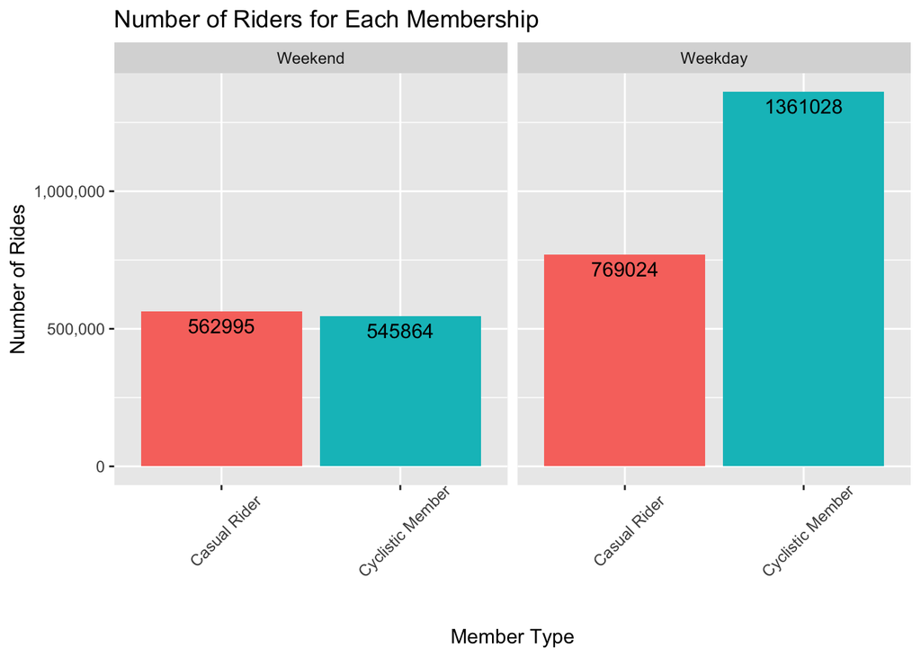

```r
weekday_label <- c("Weekend", "Weekday")
names(weekday_label) <- c("FALSE", "TRUE")
clean_data_3 %>%
  group_by(member_casual, is_weekday) %>%
  summarize(number_of_rides = n()) %>%
  ggplot(aes(x = member_casual, y= number_of_rides, fill = member_casual))+
    geom_col()+
    facet_wrap(~is_weekday, labeller = labeller(is_weekday = weekday_label))+
    labs(title = "Number of Riders for Each Membership", x = "Member Type", y = "Number of Rides")+
    scale_y_continuous(labels = scales::comma) +
    scale_x_discrete(labels = c("Casual Rider", "Cyclistic Member"))+
    theme(axis.text.x =  element_text(angle=45, margin=margin(t=20)), legend.position="none")+
    geom_text(aes(label=number_of_rides, vjust=1.5))
```

This first bar graph illustrates that the number of users during the weekend is very similar between casual riders (562,995) and Cyclistic members (545,864). However, during the weekday, it is evident that there are more Cyclistic members (1,361,028) compared to the 769,024 casual riders.

### Step 3: Plot 2 - Number of Rides by Day of the Week

Our second plot will show the number of riders for each day of the week for casual riders and Cyclistic members.

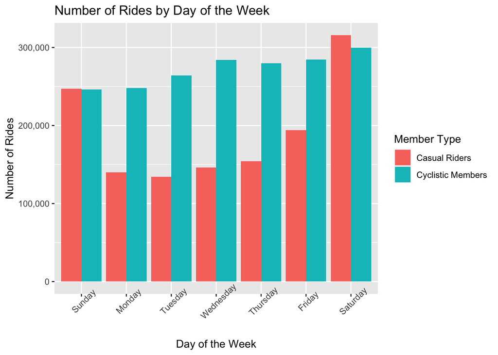

```r
rides_day_of_week <- clean_data_3 %>%
  group_by(member_casual, start_day_of_week)

rides_day_of_week %>%
  summarize(number_of_rides = n()) %>%
  arrange(member_casual, start_day_of_week) %>%
  ggplot(aes(x = start_day_of_week, y = number_of_rides, fill = member_casual)) +
    geom_col(position="dodge")+
    labs(title="Number of Rides by Day of the Week", x = "Day of the Week", y = "Number of Rides", fill = "Member Type") +
    scale_y_continuous(labels = scales::comma) +
    scale_fill_discrete(labels = c("Casual Riders", "Cyclistic Members"))+
    theme(axis.text.x = element_text(angle = 45))
```

With this bar graph, we can see that there are more riders during the weekdays for Cyclistic members. This is due to the members using the program to commute to and from work.

During the weekend, the number of rides is roughly the same between casual riders and Cyclistic members, with more casual riders on Saturdays and nearly the same number of rides between Cyclistic members and casual riders on Sundays. This shows that the number of people between casual riders and Cyclistic members that use the program for leisure purposes during the weekend is roughly the same.

### Step 4: Plot 3 - Number of Rides by Month

This third visualization will show the difference in the number of rides for each month.

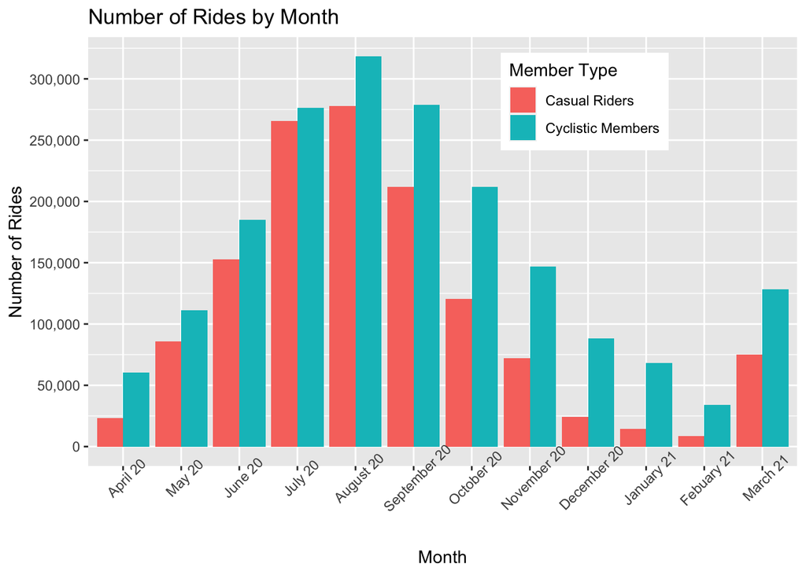

```r
monthly_rides <- clean_data_3
monthly_rides$start_month <- ordered(monthly_rides$start_month, levels = c("April", "May", "June", "July", "August", "September", "October", "November", "December", "January", "February", "March"))

monthly_rides %>%
  group_by(member_casual, start_month) %>%
  summarize(number_of_rides = n()) %>%
  arrange(member_casual, start_month) %>%
  ggplot(aes(x = start_month, y = number_of_rides, fill = member_casual)) +
    geom_col(position="dodge") +
    theme(axis.text.x = element_text(angle = 45), legend.position= c(0.7, 0.85)) +
    scale_y_continuous(labels = scales::comma, breaks=c(0, 50000, 100000, 150000, 200000, 250000, 300000)) +
    labs(title="Number of Rides by Month", x = "Month", y = "Number of Rides", fill="Member Type")+
    scale_fill_discrete(labels = c("Casual Riders", "Cyclistic Members"))+
    scale_x_discrete(labels = c( "April 20", "May 20", "June 20", "July 20", "August 20", "September 20", "October 20", "November 20", "December 20", "January 21", "Febuary 21", "March 21"))
```

Since the data we are using is from April 2020 to March 2021, our bar graph is organized as such.

### Step 5: Plot 4 - Number of Rides Started Every Hour

Plot 4 will show the number of rides that started every hour for each day of the week.

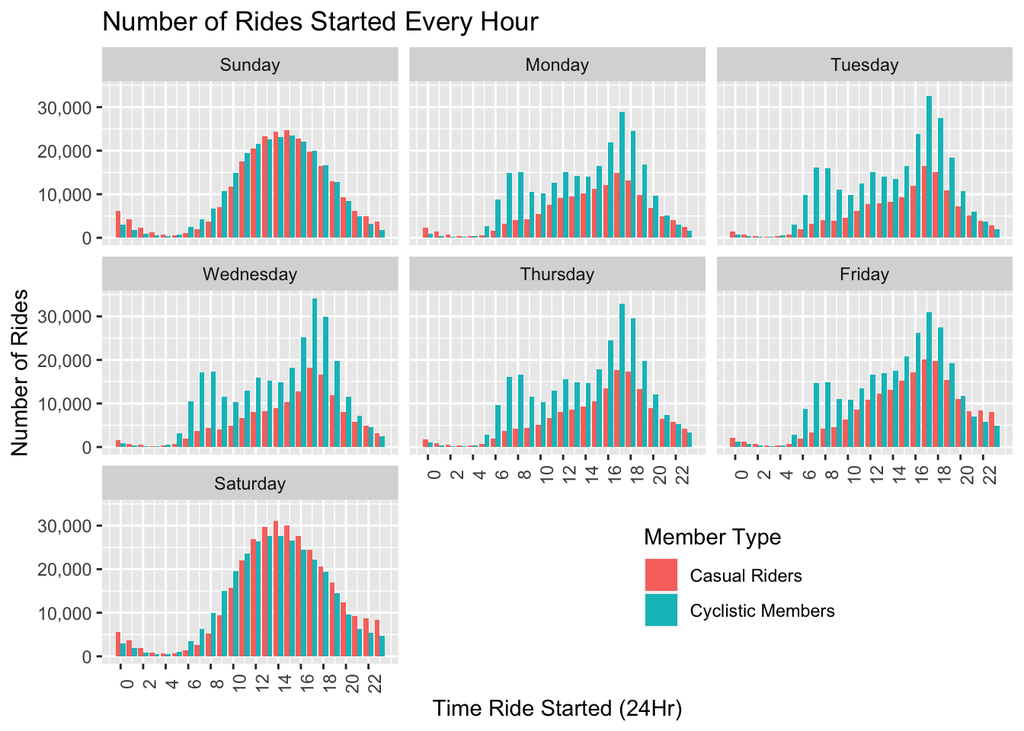

```r
hourly_rides <- clean_data_3 %>%
  mutate(start_hour = hour(started_at)) %>%
  group_by(member_casual, start_hour, start_day_of_week)

hourly_rides %>%
  summarize(number_of_rides = n()) %>%
  arrange(member_casual, start_hour) %>%
  ggplot(aes(x=start_hour, y = number_of_rides, fill = member_casual))+
    geom_col(position="dodge")+
    facet_wrap(~start_day_of_week)+
    labs(title = "Number of Rides Started Every Hour", x = "Time Ride Started (24Hr)", y = "Number of Rides", fill = "Member Type") +
    scale_fill_discrete(labels = c("Casual Riders", "Cyclistic Members"))+
    scale_y_continuous(labels = scales::comma, breaks=c(0, 10000, 20000, 30000, 40000))+
    scale_x_continuous(breaks=c(0, 2, 4, 6, 8, 10, 12, 14, 16, 18, 20, 22)) +
    theme(axis.text.x = element_text(angle = 90), legend.position= c(0.7, 0.15))
```

Plot 4 illustrates that the number of rides started at each hour on the weekends is similar between casual riders and Cyclistic members. This shows that the trends between casual riders and Cyclistic members for leisure purposes are similar. However, during the weekdays, peaks between 7 AM (7H) to 9 AM (9H) and 4 PM (16H) to 6 PM (18H) clearly show that many Cyclistic members use the program to commute to and from work. Comparatively, casual riders tend to have a gradually increasing trend of riders as the day progresses with small peaks during commute hours on Tuesdays, Wednesdays, Thursdays and Fridays.

### Step 6: Plot 5: Average Duration of Rides by Month

This next visualization shows the average duration of rides for each month.

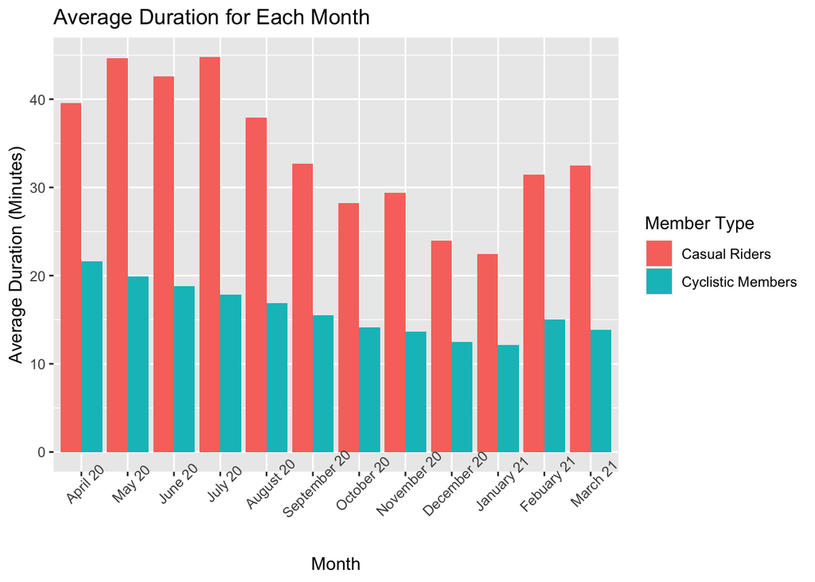

```r
monthly_rides %>%
  group_by(member_casual, start_month) %>%
  summarize(average_duration=mean(trip_duration)) %>%
  ggplot(aes(x = start_month, y = average_duration, fill = member_casual))+
  geom_col(position="dodge")+
  labs(title="Average Duration for Each Month", x = "Month", y = "Average Duration (Minutes)", fill = "Member Type") +
  theme(axis.text.x = element_text(angle = 45))+
  scale_fill_discrete(labels = c("Casual Riders", "Cyclistic Members"))+
  scale_x_discrete(labels = c("April 20", "May 20", "June 20", "July 20", "August 20", "September 20", "October 20", "November 20", "December 20", "January 21", "Febuary 21", "March 21"))
```

### Step 7: Plot 6 - Average Duration for Each Day

Similar to the last graph, this bar graph will show the average duration of rides for each day of the week.

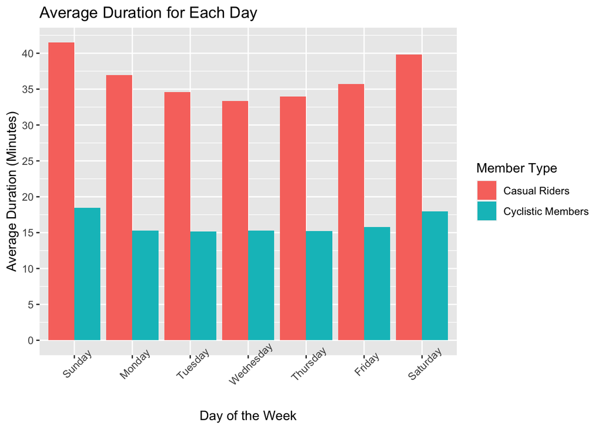

```r
clean_data_3 %>%
  group_by(member_casual, start_day_of_week) %>%
  summarize(number_of_rides = n(), average_duration = mean(trip_duration)) %>%
  arrange(number_of_rides, start_day_of_week) %>%
  ggplot(aes(x = start_day_of_week, y = average_duration, fill = member_casual))+
    geom_col(position= "dodge")+
    labs(title="Average Duration for Each Day", x = "Day of the Week", y = "Average Duration (Minutes)", fill = "Member Type")+
    scale_fill_discrete(labels = c("Casual Riders", "Cyclistic Members"))+
    scale_y_continuous(breaks = c(0, 5, 10, 15, 20, 25, 30, 35, 40, 45, 50))+
    theme(axis.text.x = element_text(angle = 45))
```

### Step 8: Plot 7 - Average Duration Every Hour

In plot 7, we can see the average duration of rides that started in each hour for each day of the week.

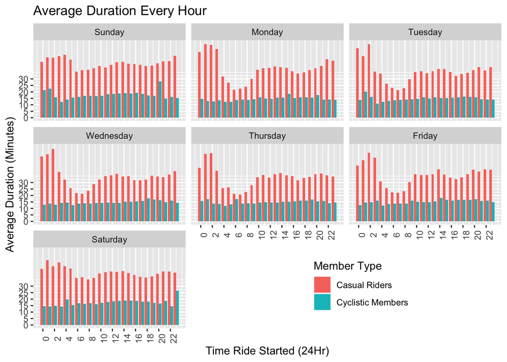

```r
hourly_rides %>%
  group_by(member_casual, start_hour, start_day_of_week) %>%
  summarize(average_duration = mean(trip_duration)) %>%
  arrange(member_casual, start_hour) %>%
  ggplot(aes(x=start_hour, y = average_duration, fill = member_casual))+
    geom_col(position="dodge") +
    facet_wrap(~start_day_of_week)+
    labs(title = "Average Duration Every Hour", x = "Time Ride Started (24Hr)", y = "Average Duration (Minutes)", fill = "Member Type") +
    scale_fill_discrete(labels = c("Casual Riders", "Cyclistic Members"))+
    scale_y_continuous(breaks = c(0, 5, 10, 15, 20, 25, 30))+
    scale_x_continuous(breaks=c(0, 2, 4, 6, 8, 10, 12, 14, 16, 18, 20, 22)) +
    theme(axis.text.x = element_text(angle = 90), legend.position= c(0.7, 0.15))
```

For casual riders, there are fluctuations between the average duration for each day. On the weekdays, there seems to be a shorter average duration during dawn and early mornings with longer average duration rides every day around 10 AM to 2 PM.

### Summary of Analysis

Plot 3 clearly illustrates the effects of weather on the number of riders each month. As expected, there are fewer riders during the winter from November to February. With peak usage during the summer months from July and August.

## Share and Act

**Deliverable: Supporting visualizations and key findings. Top three recommendations based on your analysis.**

The 7 visualizations from the Analyze sections can be used for our presentation to our stakeholders. Here is the [powerpoint presentation](https://1drv.ms/p/s!AjrEp9QDw3kvghpCFJFfZzDyVtQP?e=debmu4) with the detailed analysis and recommendations.

### Recommendations:

With the summary of our analysis from the last section, our recommendations for the stakeholders are:

- To determine which casual riders have a tendency to use Cyclistic’s services for commutes but have yet to sign up for an annual membership. These users are most likely to sign up for a Cyclistic membership to optimize savings for daily commutes.
- To target a decrease in the number of users for both casual riders and Cyclistic members, the company should look into installing winter tires for the bicycles. This could make commutes and cycling during the winter, and snowy months safer therefore increasing the number of users.
- Offer incentives for casual riders to dock their bicycles in between errands by offering a lower rate if two rentals are within a few minutes apart. Then show an annual summary to casual riders of the savings they could have achieved by signing up for an annual membership.

Additionally, the company can also offer additional pricing packages such as:

- Weekend-only packages. Instead of purchasing two full-day passes for casual riders looking for leisure uses during the weekend, they can purchase a one-weekend package and enjoy unlimited rides during the whole weekend.
- Commute packages. Allows casual riders more incentives to use the program during commute hours as opposed to driving or taking public transit.